# Network Notes

Rob Hayward

26 January 2016

# Introduction

Networks are everywhere. There are connections called *edges* between *nodes* or *vertices*. The edges can be *directed* or not. There are two main packages: `igraph`, the work of Gabor Casrdi, and `statnet` package from the University of Washington.

## Representation

Matrices can be used to represent networks

```r
A <- rbind(c(0,1,0), c(1,0,1), c(2,0,0))
nodeNames <- c("A", "B", "C")
dimnames(A) <- list(nodeNames, nodeNames)
A
```

```
##   A B C
## A 0 1 0
## B 1 0 1
## C 2 0 0
```

Where the row are from a node and the columns are to a node.

An alternative is to use an *edge list* representation.

However, the `igraph` package has its own efficient internal representation. This is most easily used by using the function `graph_from_literal`

```r
library(igraph)
g <- graph_from_literal(A++B, B-+C, C-+A)
g
```

```
## IGRAPH DN-- 3 4 --
## + attr: name (v/c)
## + edges (vertex names):
## [1] A->B B->A B->C C->A
```

It has efficient internal stricture. The output indicates that it is directed (D), it is named (N) and that it has 3 nodes and 4 edges.

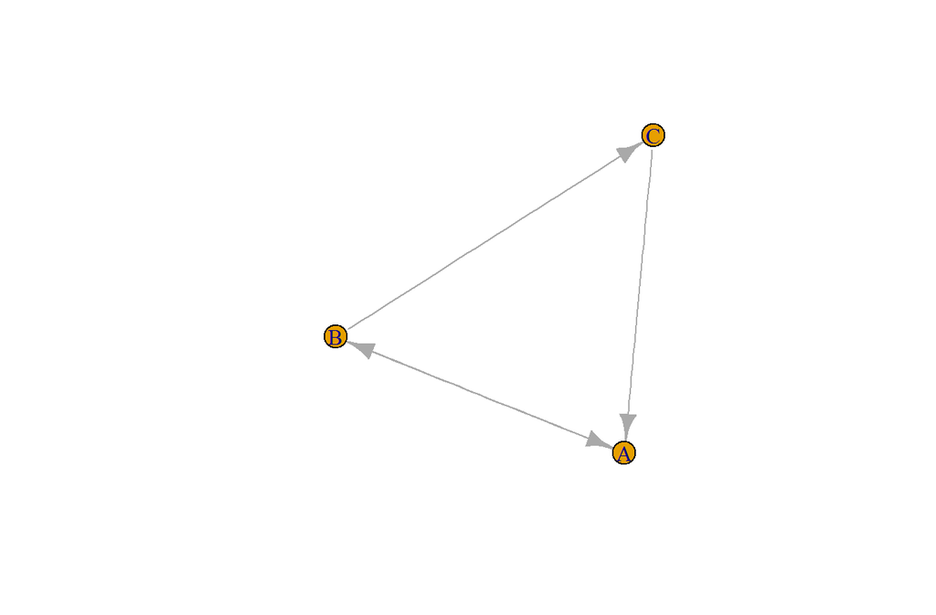

```r
plot(g)
```

igraph objects can also be made with

- edge lists `g <- graph_from_edgelist(el, directed = TRUE)`
- data frames `g <- graph_from_data_frame(df, directed = TRUE)`
- adjecency matrix `g <- graph_from_adjacency_matrix(A)`

## From graph to matrix form

It is possible move back from the graph to the matrix form

### Adjacency matrix

```r
A <- as_adjacency_matrix(g, sparse = FALSE)
A
```

```
##   A B C
## A 0 1 0
## B 1 0 1
## C 1 0 0
```

### Edge list

```r
el <- as_edgelist(g)
el
```

```
##      [,1] [,2]
## [1,] "A"  "B"
## [2,] "B"  "A"
## [3,] "B"  "C"
## [4,] "C"  "A"
```

## Standard structures

There are a range of in-built structures

### Trees

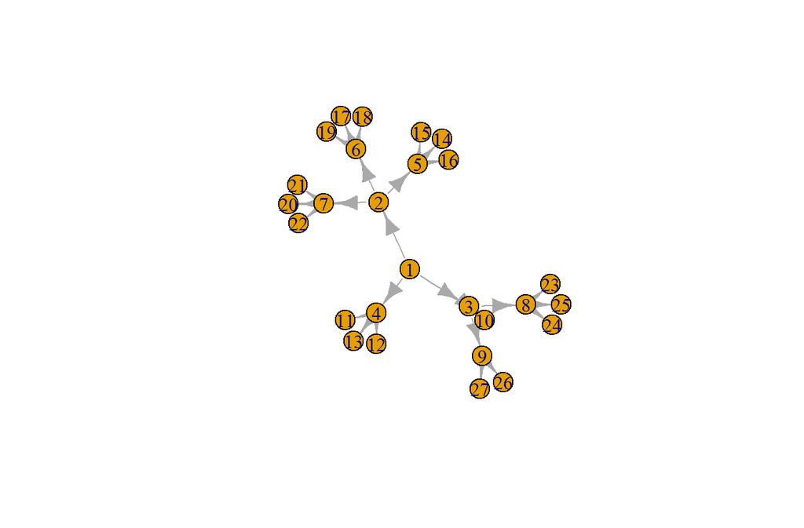

```r
g <- make_tree(27, children = 3)
plot(g)
```

### Cliques

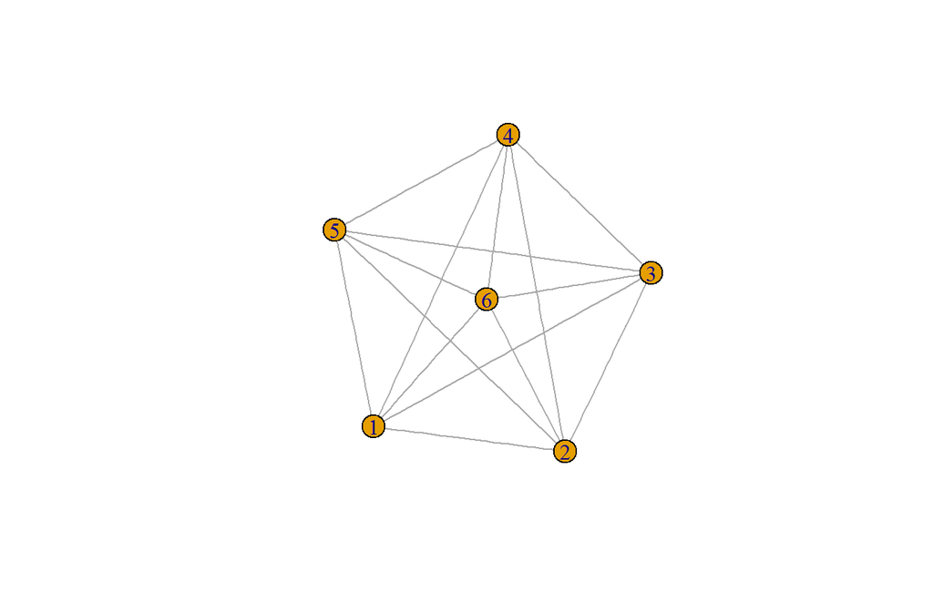

```r
g <- make_full_graph(n = 6)
plot(g)
```

### Lattices

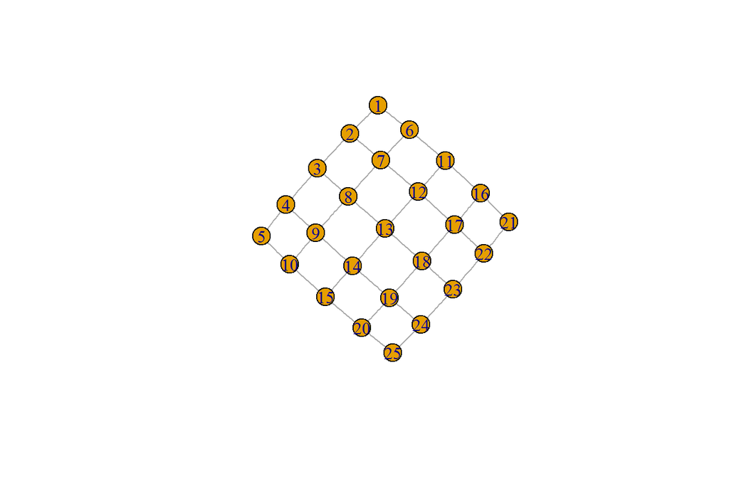

```r
g <- make_lattice(dimvector = c(5, 5), circular = FALSE)
plot(g)
```

### Stars

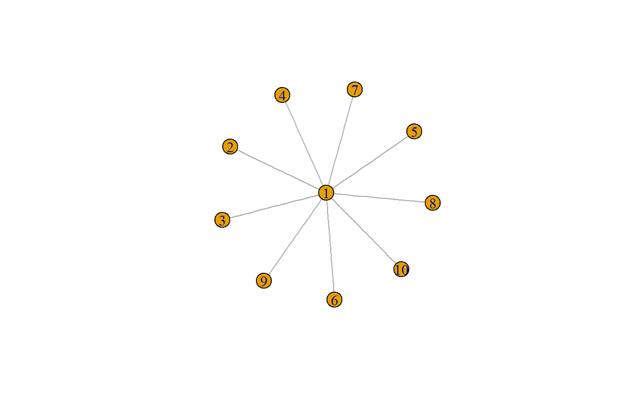

```r
g <- make_star(n = 10, mode = "undirected")
plot(g)
```

To create a start with 5 nodes and then convet the network to an adjency network

```r
g <- make_star(n = 5)
a <- as_adjacency_matrix(g)
a
```

```
## 5 x 5 sparse Matrix of class "dgCMatrix"
##
## [1,] . . . . .
## [2,] 1 . . . .
## [3,] 1 . . . .
## [4,] 1 . . . .
## [5,] 1 . . . .
```